# 01. Tutorial to generate comprehensive heatmaps to show results on all combinations

Edoardo Giuili

2025-09-23

## Introduction

This is the first notebook to reproduce the analysis of the bench.resmarking results. More specifically, in this notebook we will go over the results obtained on the in-silico mixtures. In total, 1640 WGBS, 1550 and 440 samples (WGBS, RRBS and MNase-cfRRBS, respectively) have been deconvolved. These samples were generated at different sequencing depths, spanning 10 expected tumor fractions, different tumor types and using 3 DMR selection tools. We will therefore generate plots for all these combinations, step by step.

### Setting up the environment

First, set up the main directory

```r
# Don't change this if you git cloned the entire GitHub repository and you are working in the notebooks/ folder
knitr::opts_knit$set(root.dir = './')
```

Import the necessary libraries for the analysis

```r
library(ggpubr)
library(dplyr)
library(tidyverse)
library(ComplexHeatmap)
library(stringr)
library(pROC)
```

Import the useful functions and the metrics

```r
source("../R/compute_auc.R")

# RMSE
rmse <- function(actual, predicted) {
  round(sqrt(mean((actual - predicted)^2)),4)
}
# Normalized RMSE (NRMSE)
nrmse <- function(actual, predicted) {
    round(sqrt(mean((actual - predicted))^2)/mean(actual+10e-8),4)
}
# Spearman's rank correlation coefficient (SCC)
scc <- function(actual, predicted) {
  cor(actual, predicted, method = "spearman", use = "pairwise.complete.obs")
}
```

Now, we will import all the results generated and described above. Note that here we expect that you have git cloned the repository and thus have the expected folder structure where in the folder resources/ there are the results files.

```r
df_raw <- read.csv("../resources/final_benchmarking_dataset.csv")
bench.res <- subset(df_raw, df_raw$mixture_type == "in_silico")
```

### Missing values

An important aspect to take into consideration is the number of missing values per tool.

```r
missing_percentage <- bench.res %>%
     group_by(deconv_tool) %>%
     summarise(
         total = n(),
         missing = sum(is.na(predicted_tf)),
         percent_missing = 100 * missing / total
     )
missing_percentage
```

```
## # A tibble: 10 × 4
##    deconv_tool     total missing percent_missing
##    <chr>           <int>   <int>           <dbl>
##  1 CIBERSORT       11880       0          0
##  2 CelFiE          11880       0          0
##  3 EpiDISH_CP_eq   11880       0          0
##  4 EpiDISH_CP_ineq 11880       0          0
##  5 EpiDISH_RPC     11880       7          0.0589
##  6 EpiSCORE        11880       2          0.0168
##  7 MetDecode       11880       0          0
##  8 PRMeth          11880       0          0
##  9 UXM             11880       0          0
## 10 meth_atlas      11880       0          0
```

Since the presence of missing values is very low (meaning that all the tools almost always produce an output), we will just remove them without penalizing the tools that produced missing values or imputing them.

```r
# Remove rows with NA values for further analysis
bench.res <- bench.res %>%
  filter(!is.na(predicted_tf))
```

## Plot the results

### Heatmap of all combinations

As a first step in the analysis, we think that a comphrensive heatamap of all possible combinations might be useful as a starting point. We will first compute the metrics necessary for the heatmap: being RMSE, AUC-ROC score, SCC and the overall Score. Since the RMSE is not a scale-free metric, it will increase at increasing observed tumoral fraction. This determines that the RMSE at high tumoral fraction (e.g. 0.25 and 0.5) will dominate the overall and advantage those tools that perform well uniquely at high tumoral fractions. To account for this bias, we have decided to compute the RMSE separately at each observed tumoral fraction within each combination, then min-max scale it across deconvolution tools and aggregate the individual min-max scaled RMSE at each tumoral fraction using the mean to get a unique RMSE per combination.

```r
rmse_minmax <- bench.res %>%
  filter(expected_tf != 0) %>%
  group_by(deconv_tool, dmr_tool, seq_depth, tumor_type, expected_tf) %>%
  mutate(RMSE = rmse(expected_tf, predicted_tf)) %>%
  ungroup() %>%
  group_by(dmr_tool, seq_depth, tumor_type, expected_tf) %>%
  mutate(
    RMSE_min = min(RMSE),
    RMSE_max = max(RMSE),
    RMSE_minmax = (RMSE - RMSE_min) / (RMSE_max - RMSE_min)
  ) %>%
  group_by(deconv_tool, dmr_tool, seq_depth, tumor_type) %>%
  summarise(RMSE = 1-mean(RMSE_minmax), .groups = "drop")
```

Then we compute the AUC for each tool. To compute it, we will loop over each combination and calculate the AUC-ROC score at each tumor fraction. Then, to get an estimation of the AUC-ROC score per combination, we will average the individual AUC-ROC scores per fraction. We will finally min-max scale it as we did with the RMSE.

```r
# Create a new dataset dataframe where to store AUC-ROC results
aucroc_data <- data.frame()
# Select the samples with tumoral fractions > 0%
unique_fractions <- unique(bench.res$expected_tf)
unique_fractions <- subset(unique_fractions, unique_fractions != 0)

# Loop over the type of tumors
for (type in unique(bench.res$tumor_type)) {

  # Loop over sequencing depths
  filt_tum <- subset(bench.res, bench.res$tumor_type == type)
  for (seqdepth in unique(filt_tum$seq_depth)) {

    # Loop over the DMR tools
    filt_depth <- subset(filt_tum, filt_tum$seq_depth == seqdepth)
    for (dmrtool in unique(filt_depth$dmr_tool)) {

      # Loop over the deconvolution tools
      for (deconv in unique(filt_depth$deconv_tool)) {

        # Loop over the tumoral fractions specified above
        for (fraction in unique_fractions) {
          filt_df <- filt_depth %>%
            filter(expected_tf %in% c(0,fraction) &
                   dmr_tool == dmrtool &
                   deconv_tool == deconv)

          # Compute the AUC-ROC score per combination and concatanate it to the final dataframe
          auc_single_combination <- compute_auc(filt_df, fraction, deconv)
          aucroc_data <- rbind(aucroc_data, auc_single_combination)
        }
      }
    }
  }
}
auc_minmax <- aucroc_data %>%
    group_by(deconv_tool, dmr_tool, seq_depth, tumor_type, expected_tf) %>%
    summarize(AUC=mean(auc),.groups = "drop") %>%
    group_by(deconv_tool, dmr_tool, seq_depth, tumor_type) %>%
    summarize(meanAUC=mean(AUC),.groups = "drop") %>%
    group_by(dmr_tool, seq_depth, tumor_type) %>%
    mutate(
      AUC_min = min(meanAUC),
      AUC_max = max(meanAUC),
      AUC_minmax = (meanAUC - AUC_min) / (AUC_max - AUC_min)
    ) %>%
    group_by(deconv_tool, dmr_tool, seq_depth, tumor_type) %>%
    summarise(AUC = AUC_minmax, .groups = "drop")
```

Finally, we compute the SCC. The SCC is computed for each combination pooling all the observed tumor fractions together to get a value for each combination. The SCC is then min-max scaled.

```r
# Compute the metrics: modify the RMSE= 1) nrmse 2) rmse 3) rmse of logit(values)
scc_minmax <- bench.res %>%
  group_by(deconv_tool, dmr_tool, seq_depth, tumor_type) %>%
  summarise(SCC = cor(expected_tf, predicted_tf, method = "spearman"), .groups = "drop") %>%
  ungroup() %>%
  group_by(dmr_tool, seq_depth, tumor_type) %>%
  mutate(
    SCC_min = min(SCC),
    SCC_max = max(SCC),
    SCC_minmax = (SCC - SCC_min) / (SCC_max - SCC_min)
  ) %>%
  group_by(deconv_tool, dmr_tool, seq_depth, tumor_type) %>%
  summarise(SCC = SCC_minmax, .groups = "drop")
```

We can now combine these metrics into a unique dataframe.

```r
df.metrics <- rmse_minmax %>%
  left_join(scc_minmax) %>%
  left_join(auc_minmax)
```

To get an overview of the combined metrics and compute an overall score, we will just aggregate them using a weighted average as previously described.

```r
# Compute the number of zeros and non-zero observations
num.zeros <- nrow(bench.res[bench.res$expected_tf==0,])
num.nonzeros <- nrow(bench.res[bench.res$expected_tf!=0,])

# Compute the total number of observation
tot <- num.nonzeros + num.zeros

# Compute the Score
df.metrics$Score <- df.metrics$SCC + ( num.nonzeros/tot )*df.metrics$RMSE + df.metrics$AUC
```

### Plot the data of WGBS

We are now ready to plot an comprehensive heatmap of the WGBS dataset describing all the different combinations. We will first subset the metrics dataframe and retain only the tumor samples belonging to the WGBS dataset.

```r
final_wgbs_df <- df.metrics %>% filter(tumor_type %in% c("LUAD","LUSC","BRCA","BLCA"))
```

Change the format of the dataframe to a long format

```r
# Create 2 columns corresponding to the deconvolution tool names collapsed with the sequencing depths and dmr tools
final_wgbs_df_mutated <- final_wgbs_df %>%
  mutate(tool_dmr_combination = paste(deconv_tool, dmr_tool, sep = "_")) %>%
  mutate(tumor_seq_combination = paste(tumor_type, seq_depth, sep = "_"))

# Make a long format of the df
final_wgbs_df_long <- final_wgbs_df_mutated %>%
  pivot_longer(
    cols = c(RMSE,AUC,SCC,Score),
    names_to = "metric",
    values_to = "value"
  ) %>%
  group_by(tool_dmr_combination, metric, tumor_seq_combination) %>%
  summarise(value = value, .groups = "drop")
```

Now, per metric, select only the column corresponding to it, go back to the wider format and transform it to a matrix.

```r
# Specify the order of the columns for visualization purposes
desired_order <- c("LUAD_62M", "LUAD_183M", "LUAD_310M", "LUAD_620M",
                   "LUSC_62M", "LUSC_183M", "LUSC_310M", "LUSC_620M",
                   "BRCA_62M", "BRCA_183M", "BRCA_310M", "BRCA_620M",
                   "BLCA_62M", "BLCA_183M", "BLCA_310M", "BLCA_620M")

# AUC matrix
wgbs_auc_mat <- final_wgbs_df_long %>%
  filter(metric == "AUC") %>%
  select(tool_dmr_combination, tumor_seq_combination, value) %>%
  pivot_wider(names_from = tumor_seq_combination, values_from = value) %>%
  column_to_rownames("tool_dmr_combination") %>%
  as.matrix()
wgbs_auc_mat <- wgbs_auc_mat[, desired_order]

# RMSE matrix
wgbs_rmse_mat <- final_wgbs_df_long %>%
  filter(metric == "RMSE") %>%
  select(tool_dmr_combination, tumor_seq_combination, value) %>%
  pivot_wider(names_from = tumor_seq_combination, values_from = value) %>%
  column_to_rownames("tool_dmr_combination") %>%
  as.matrix()
wgbs_rmse_mat <- wgbs_rmse_mat[, desired_order]

# SCC matrix
wgbs_scc_mat <- final_wgbs_df_long %>%
  filter(metric == "SCC") %>%
  select(tool_dmr_combination, tumor_seq_combination, value) %>%
  pivot_wider(names_from = tumor_seq_combination, values_from = value) %>%
  column_to_rownames("tool_dmr_combination") %>%
  as.matrix()
wgbs_scc_mat <- wgbs_scc_mat[, desired_order]

# Score matrix
wgbs_score_mat <- final_wgbs_df_long %>%
  filter(metric == "Score") %>%
  select(tool_dmr_combination, tumor_seq_combination, value) %>%
  pivot_wider(names_from = tumor_seq_combination, values_from = value) %>%
  column_to_rownames("tool_dmr_combination") %>%
  as.matrix()
wgbs_score_mat <- wgbs_score_mat[, desired_order]
```

Order the rows based on the Score values to give kind of a ranking

```r
# Compute row means of the Score matrix
score_means <- rowMeans(wgbs_score_mat, na.rm = TRUE)

# Order the row names based on descending Score (you can use decreasing = FALSE for ascending)
ordered_rows <- names(sort(score_means, decreasing = TRUE))

# Reorder all matrices by the ordered row names
wgbs_score_mat <- wgbs_score_mat[ordered_rows, ]
wgbs_auc_mat   <- wgbs_auc_mat[ordered_rows, ]
wgbs_rmse_mat  <- wgbs_rmse_mat[ordered_rows, ]
wgbs_scc_mat   <- wgbs_scc_mat[ordered_rows, ]
```

And now we can plot the results in a heatmap using ComplexHeatmap package.

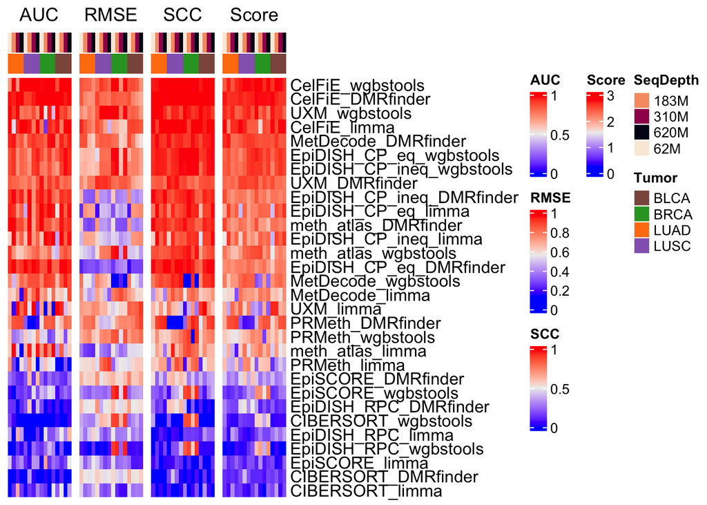

```r
# Define tumor types and sequencing depths for the annotations
seq_depth <- rep(c("62M", "183M", "310M", "620M"), 4)
tumors    <- rep(c("LUAD", "LUSC", "BRCA", "BLCA"), each = 4)

# Assign palettes
col_anno <- HeatmapAnnotation(
  SeqDepth = seq_depth,
  Tumor    = tumors,
  col = list(
    SeqDepth = c("62M"="#FAEBDDFF","183M"="#F69C73FF","310M"="#A11A5BFF","620M"="#03051AFF"),
    Tumor = c("LUAD"="#ff7f0e", "BRCA"="#2ca02c",
              "LUSC"="#9467bd", "BLCA"="#8c564b")
  ),
  show_annotation_name = FALSE
)

# Define heatmap settings shared across all plots
common_opts <- list(
  cluster_rows = FALSE,
  cluster_columns = FALSE,
  column_names_rot = 45,
  show_row_dend = TRUE,
  show_column_names = FALSE,
  show_column_dend = FALSE,
  top_annotation = col_anno,
  column_labels = tumors
)

# Put all matrices and their titles/names in a list
heatmap_data <- list(
  AUC         = wgbs_auc_mat,
  RMSE        = wgbs_rmse_mat,
  SCC         = wgbs_scc_mat,
  Score       = wgbs_score_mat
)

# Generate heatmaps with do.call
heatmaps <- lapply(names(heatmap_data), function(name) {
  do.call(Heatmap, c(
    list(
      matrix = heatmap_data[[name]],
      name = name,
      column_title = name
    ),
    common_opts
  ))
})
draw(Reduce(`+`, heatmaps))
```

```r
# Create the main directory to save the plots
output_dir <- "../plots/01_comprehensive_heatmaps"
if (!dir.exists(output_dir)) dir.create(output_dir)

# Combine and draw
pdf(paste0(output_dir,"/wgbs_heatmap.pdf"), width = 12, height = 6)
draw(Reduce(`+`, heatmaps))
dev.off()
```

### Plot the data of RRBS

Here we will follow the same steps as before, but for the RRBS dataset.

```r
final_rrbs_df <- df.metrics %>% filter(tumor_type %in% c("CRC","LC","PC"))
```

```r
# Create 2 columns corresponding to the deconvolution tool names collapsed with the sequencing depths and dmr tools
final_rrbs_df_mutated <- final_rrbs_df %>%
  mutate(tool_dmr_combination = paste(deconv_tool, dmr_tool, sep = "_")) %>%
  mutate(tumor_seq_combination = paste(tumor_type, seq_depth, sep = "_"))

# Make a long format of the df
final_rrbs_df_long <- final_rrbs_df_mutated %>%
  pivot_longer(
    cols = c(RMSE,AUC,SCC,Score),
    names_to = "metric",
    values_to = "value"
  ) %>%
  group_by(tool_dmr_combination, metric, tumor_seq_combination) %>%
  summarise(value = value, .groups = "drop")
```

```r
# Specify the order of the columns for visualization purposes
desired_order <- c("LC_2M","LC_5M", "LC_10M", "LC_15M", "LC_20M",
                   "CRC_2M","CRC_5M", "CRC_10M", "CRC_15M", "CRC_20M",
                   "PC_2M","PC_5M", "PC_10M", "PC_15M", "PC_20M")

# AUC matrix
rrbs_auc_mat <- final_rrbs_df_long %>%
  filter(metric == "AUC") %>%
  select(tool_dmr_combination, tumor_seq_combination, value) %>%
  pivot_wider(names_from = tumor_seq_combination, values_from = value) %>%
  column_to_rownames("tool_dmr_combination") %>%
  as.matrix()
rrbs_auc_mat <- rrbs_auc_mat[, desired_order]

# RMSE matrix
rrbs_rmse_mat <- final_rrbs_df_long %>%
  filter(metric == "RMSE") %>%
  select(tool_dmr_combination, tumor_seq_combination, value) %>%
  pivot_wider(names_from = tumor_seq_combination, values_from = value) %>%
  column_to_rownames("tool_dmr_combination") %>%
  as.matrix()
rrbs_rmse_mat <- rrbs_rmse_mat[, desired_order]

# SCC matrix
rrbs_scc_mat <- final_rrbs_df_long %>%
  filter(metric == "SCC") %>%
  select(tool_dmr_combination, tumor_seq_combination, value) %>%
  pivot_wider(names_from = tumor_seq_combination, values_from = value) %>%
  column_to_rownames("tool_dmr_combination") %>%
  as.matrix()
rrbs_scc_mat <- rrbs_scc_mat[, desired_order]

# Score matrix
rrbs_score_mat <- final_rrbs_df_long %>%
  filter(metric == "Score") %>%
  select(tool_dmr_combination, tumor_seq_combination, value) %>%
  pivot_wider(names_from = tumor_seq_combination, values_from = value) %>%
  column_to_rownames("tool_dmr_combination") %>%
  as.matrix()
rrbs_score_mat <- rrbs_score_mat[, desired_order]
```

```r
# Compute row means of the Score matrix
score_means <- rowMeans(rrbs_score_mat, na.rm = TRUE)

# Order the row names based on descending Score (you can use decreasing = FALSE for ascending)
ordered_rows <- names(sort(score_means, decreasing = TRUE))

# Reorder all matrices by the ordered row names
rrbs_score_mat <- rrbs_score_mat[ordered_rows, ]
rrbs_auc_mat   <- rrbs_auc_mat[ordered_rows, ]
rrbs_rmse_mat  <- rrbs_rmse_mat[ordered_rows, ]
rrbs_scc_mat   <- rrbs_scc_mat[ordered_rows, ]
```

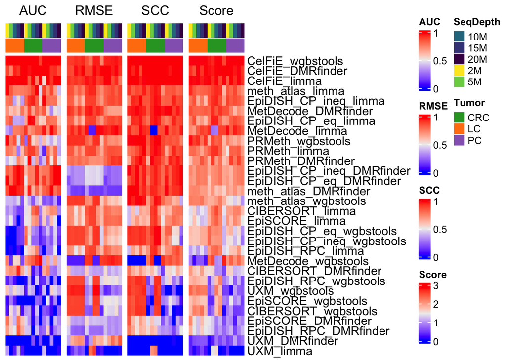

```r
seq_depth <- rep(c("2M", "5M", "10M", "15M", "20M"), 3)
tumors    <- rep(c("LC", "CRC", "PC"), each = 5)

col_anno <- HeatmapAnnotation(
  SeqDepth = seq_depth,
  Tumor    = tumors,
  col = list(
    SeqDepth = c("2M"="#FDE725FF","5M"="#7AD151FF","10M"="#2A788EFF","15M"="#414487FF","20M"="#440154FF"),
    Tumor = c("LC"="#ff7f0e", "CRC"="#2ca02c", "PC"="#9467bd")
  ),
  show_annotation_name = FALSE
)

# Define heatmap settings shared across all plots
common_opts <- list(
  cluster_rows = FALSE,
  cluster_columns = FALSE,
  column_names_rot = 45,
  show_row_dend = TRUE,
  show_column_names = FALSE,
  show_column_dend = FALSE,
  top_annotation = col_anno,
  column_labels = tumors
)

# Put all matrices and their titles/names in a list
heatmap_data <- list(
  AUC         = rrbs_auc_mat,
  RMSE        = rrbs_rmse_mat,
  SCC         = rrbs_scc_mat,
  Score       = rrbs_score_mat
)

# Generate heatmaps with do.call
heatmaps <- lapply(names(heatmap_data), function(name) {
  do.call(Heatmap, c(
    list(
      matrix = heatmap_data[[name]],
      name = name,
      column_title = name
    ),
    common_opts
  ))
})
draw(Reduce(`+`, heatmaps))
```

### Plot the data of cfRRBS

Here we will follow the same steps as before, but for the cfRRBS dataset.

```r
final_cfrrbs_df <- df.metrics %>% filter(tumor_type %in% c("NBL"))
```

```r
# Create 2 columns corresponding to the deconvolution tool names collapsed with the sequencing depths and dmr tools
final_cfrrbs_df_mutated <- final_cfrrbs_df %>%
  mutate(tool_dmr_combination = paste(deconv_tool, dmr_tool, sep = "_")) %>%
  mutate(tumor_seq_combination = paste(tumor_type, seq_depth, sep = "_"))

# Make a long format of the df
final_cfrrbs_df_long <- final_cfrrbs_df_mutated %>%
  pivot_longer(
    cols = c(RMSE,AUC,SCC,Score),
    names_to = "metric",
    values_to = "value"
  ) %>%
  group_by(tool_dmr_combination, metric, tumor_seq_combination) %>%
  summarise(value = value, .groups = "drop")
```

```r
# Specify the order of the columns for visualization purposes
desired_order <- c("NBL_2M","NBL_5M", "NBL_10M", "NBL_15M", "NBL_20M")

# AUC matrix
cfrrbs_auc_mat <- final_cfrrbs_df_long %>%
  filter(metric == "AUC") %>%
  select(tool_dmr_combination, tumor_seq_combination, value) %>%
  pivot_wider(names_from = tumor_seq_combination, values_from = value) %>%
  column_to_rownames("tool_dmr_combination") %>%
  as.matrix()
cfrrbs_auc_mat <- cfrrbs_auc_mat[, desired_order]

# RMSE matrix
cfrrbs_rmse_mat <- final_cfrrbs_df_long %>%
  filter(metric == "RMSE") %>%
  select(tool_dmr_combination, tumor_seq_combination, value) %>%
  pivot_wider(names_from = tumor_seq_combination, values_from = value) %>%
  column_to_rownames("tool_dmr_combination") %>%
  as.matrix()
cfrrbs_rmse_mat <- cfrrbs_rmse_mat[, desired_order]

# SCC matrix
cfrrbs_scc_mat <- final_cfrrbs_df_long %>%
  filter(metric == "SCC") %>%
  select(tool_dmr_combination, tumor_seq_combination, value) %>%
  pivot_wider(names_from = tumor_seq_combination, values_from = value) %>%
  column_to_rownames("tool_dmr_combination") %>%
  as.matrix()
cfrrbs_scc_mat <- cfrrbs_scc_mat[, desired_order]

# Score matrix
cfrrbs_score_mat <- final_cfrrbs_df_long %>%
  filter(metric == "Score") %>%
  select(tool_dmr_combination, tumor_seq_combination, value) %>%
  pivot_wider(names_from = tumor_seq_combination, values_from = value) %>%
  column_to_rownames("tool_dmr_combination") %>%
  as.matrix()
cfrrbs_score_mat <- cfrrbs_score_mat[, desired_order]
```

```r
# Compute row means of the Score matrix
score_means <- rowMeans(rrbs_score_mat, na.rm = TRUE)

# Order the row names based on descending Score (you can use decreasing = FALSE for ascending)
ordered_rows <- names(sort(score_means, decreasing = TRUE))

# Reorder all matrices by the ordered row names
cfrrbs_score_mat <- cfrrbs_score_mat[ordered_rows, ]
cfrrbs_auc_mat   <- cfrrbs_auc_mat[ordered_rows, ]
cfrrbs_rmse_mat  <- cfrrbs_rmse_mat[ordered_rows, ]
cfrrbs_scc_mat   <- cfrrbs_scc_mat[ordered_rows, ]
```

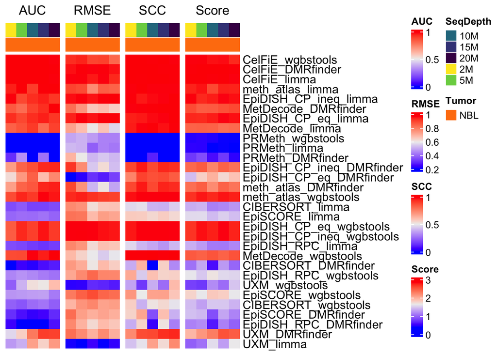

```r
seq_depth <- rep(c("2M", "5M", "10M", "15M", "20M"), 1)
tumors    <- rep(c("NBL"), each = 5)

col_anno <- HeatmapAnnotation(
  SeqDepth = seq_depth,
  Tumor    = tumors,
  col = list(
    SeqDepth = c("2M"="#FDE725FF","5M"="#7AD151FF","10M"="#2A788EFF","15M"="#414487FF","20M"="#440154FF"),
    Tumor = c("NBL"="#ff7f0e")
  ),
  show_annotation_name = FALSE
)

# Define heatmap settings shared across all plots
common_opts <- list(
  cluster_rows = FALSE,
  cluster_columns = FALSE,
  column_names_rot = 45,
  show_row_dend = TRUE,
  show_column_names = FALSE,
  show_column_dend = FALSE,
  top_annotation = col_anno,
  column_labels = tumors
)

# Put all matrices and their titles/names in a list
heatmap_data <- list(
  AUC         = cfrrbs_auc_mat,
  RMSE        = cfrrbs_rmse_mat,
  SCC         = cfrrbs_scc_mat,
  Score       = cfrrbs_score_mat
)

# Generate heatmaps with do.call
heatmaps <- lapply(names(heatmap_data), function(name) {
  do.call(Heatmap, c(
    list(
      matrix = heatmap_data[[name]],
      name = name,
      column_title = name
    ),
    common_opts
  ))
})
draw(Reduce(`+`, heatmaps))
```